# RETRASCORE - Árboles de decisión y puntos de corte de AIS por región anatómica

Exploración con retrauci_abril_2026.csv y mortalidad a 30 días

2026-11-06

# 1 Objetivo

Explorar si los **árboles de decisión** permiten encontrar **puntos de corte de la gravedad AIS** que se asocien con la **mortalidad a 30 días**, **región anatómica por región anatómica**. Para cada una de las 9 regiones AIS se usa como predictor el **AIS máximo del paciente en esa región** (0 = sin lesión registrada, 1-6 = gravedad AIS) y se buscan los cortes de tres maneras:

1. **Youden**: el corte que maximiza sensibilidad + especificidad - 1.
2. **Árbol de clasificación (`rpart`, criterio de Gini)** con una sola partición.
3. **Árbol de inferencia condicional (`ctree`)** con una sola partición; usa tests de permutación y corrige por comparaciones múltiples.

Después se comprueba la **estabilidad** de cada corte con *bootstrap*, se repite el análisis en pacientes con **lesión aislada** en la región (para que el corte no esté contaminado por lesiones en otras regiones) y se ajusta un **árbol multivariante** con las 9 regiones a la vez, validado en una muestra de test.

Los cortes que se obtienen aquí son **exploratorios**: se buscan y se evalúan en los mismos datos (salvo el bloque de train/test), así que el rendimiento de un corte “óptimo” es optimista. La tabla de estabilidad por *bootstrap* sirve precisamente para ver cuánto depende la elección de la muestra.

# 2 Parámetros

```r
input_candidates <- c("../retrauci_abril_2026.csv", "retrauci_abril_2026.csv")
input_file <- input_candidates[file.exists(input_candidates)][1]
output_dir <- "outputs_arboles_regiones_ais"

year_range <- c(2015L, 2025L)   # año del trauma
minimum_age <- 18               # se eliminan los menores de 18 años
number_of_lesions <- 32L
severe_threshold <- 3           # corte convencional de referencia: AIS >= 3

min_bucket_univariate <- 30L    # pacientes mínimos a cada lado de un corte
min_bucket_isolated <- 20L      # idem en el análisis de lesión aislada
min_bucket_tree <- 50L          # pacientes mínimos por hoja (árbol multivariante)
max_depth_tree <- 4L            # profundidad máxima del árbol multivariante
n_bootstrap <- 1000L            # réplicas bootstrap para la estabilidad
test_fraction <- 0.30           # fracción de test en el árbol multivariante
exclude_without_lesions <- TRUE # excluir pacientes sin ninguna lesión válida
seed <- 20261106L

region_names <- c(
  "Craneo", "Cara", "Cuello", "Torax", "Abdomen",
  "Columna vertebral", "Extremidades superiores",
  "Extremidades inferiores", "Piel y partes blandas"
)
# Nombres sintácticos para usar como variables en los modelos.
region_vars <- c("Craneo", "Cara", "Cuello", "Torax", "Abdomen",
                 "Columna", "Ext_sup", "Ext_inf", "Piel")

if (is.na(input_file)) {
  stop("No se encuentra retrauci_abril_2026.csv ni en la carpeta del ",
       "documento ni en la carpeta superior.")
}
dir.create(output_dir, showWarnings = FALSE)
set.seed(seed)
```

# 3 Lectura y preparación de datos

```r
# Todo se lee como texto para no alterar identificadores ni códigos.
raw_data <- read.csv2(
  input_file,
  stringsAsFactors = FALSE,
  colClasses = "character",
  na.strings = NULL
)

clean_text <- function(x) {
  x <- tolower(trimws(as.character(x)))
  x[x %in% c("", "na", "nas")] <- NA_character_
  x
}

clean_number <- function(x) {
  x <- trimws(as.character(x))
  x[x %in% c("", "NA", "NAS")] <- NA_character_
  suppressWarnings(as.numeric(gsub(",", ".", x)))
}

parse_dates <- function(x) {
  x <- trimws(as.character(x))
  x[x %in% c("", "NA", "NAS")] <- NA_character_
  suppressWarnings(
    parse_date_time(x, orders = c("dmy", "ymd", "dmy HMS", "ymd HMS"))
  )
}

trauma_date <- parse_dates(raw_data$fecha_trauma)
icu_discharge_date <- parse_dates(raw_data$fecha_alta_uci)
hospital_discharge_date <- parse_dates(raw_data$fecha_alta_hospital)
death_recorded_date <- parse_dates(raw_data$fecha_exitus)
```

## 3.1 Mortalidad a 30 días

Misma definición que en `heatmap_lesiones_ais.Rmd`: mortalidad intrahospitalaria a partir de `evolucion_uci` y `evolucion_hospitalaria`; vale 1 si el paciente fallece en los 30 días siguientes al trauma y 0 si sobrevive al alta o fallece después del día 30. Los fallecidos sin fecha válida quedan con desenlace desconocido y se excluyen.

```r
death_labels <- c("exitus", "exitus y donacion")
icu_outcome <- clean_text(raw_data$evolucion_uci)
hospital_outcome <- clean_text(raw_data$evolucion_hospitalaria)

in_hospital_mortality <- case_when(
  icu_outcome %in% death_labels ~ 1L,
  hospital_outcome %in% death_labels ~ 1L,
  hospital_outcome == "alta" ~ 0L,
  TRUE ~ NA_integer_
)

icu_death <- icu_outcome %in% death_labels
hospital_death <- hospital_outcome %in% death_labels

death_date <- as.POSIXct(
  rep(NA_real_, nrow(raw_data)),
  origin = "1970-01-01", tz = "UTC"
)
death_date[icu_death] <- icu_discharge_date[icu_death]
death_date[hospital_death] <- hospital_discharge_date[hospital_death]

use_recorded_date <- in_hospital_mortality == 1 & is.na(death_date) &
  !is.na(death_recorded_date)
use_recorded_date[is.na(use_recorded_date)] <- FALSE
death_date[use_recorded_date] <- death_recorded_date[use_recorded_date]

days_to_death <- as.numeric(
  difftime(death_date, trauma_date, units = "days")
)
valid_death_date <- !is.na(days_to_death) & days_to_death >= 0

mortality_30d <- case_when(
  in_hospital_mortality == 0 ~ 0L,
  in_hospital_mortality == 1 & valid_death_date & days_to_death <= 30 ~ 1L,
  in_hospital_mortality == 1 & valid_death_date & days_to_death > 30 ~ 0L,
  TRUE ~ NA_integer_
)
```

## 3.2 Regiones AIS y AIS máximo por región

El archivo de abril tiene muchas lesiones con nombre pero **sin región AIS** informada. Igual que en `completar_regiones_ais.Rmd`, la región vacía se completa con el texto del nombre de la lesión anterior a la primera `/`; los valores ya informados se respetan siempre que sean regiones válidas (1-9). Las lesiones sin gravedad AIS válida (1-6) no se pueden usar y se ignoran.

```r
region_map <- c(
  "craneo" = 1, "cara" = 2, "cuello" = 3, "torax" = 4, "abdomen" = 5,
  "columna vertebral" = 6, "extremidades superiores" = 7,
  "extemidades inferiores" = 8,  # grafía tal como aparece en el archivo
  "extremidades inferiores" = 8, "piel y partes blandas" = 9
)

region_from_text <- function(lesion_name) {
  lesion_name <- clean_text(lesion_name)
  region_text <- trimws(sub("/.*$", "", lesion_name))
  unname(region_map[region_text])
}

name_cols <- paste0("lesion_", 0:(number_of_lesions - 1L), "_nombre")
region_cols <- paste0("lesion_", 0:(number_of_lesions - 1L), "_region_ais")
severity_cols <- paste0("lesion_", 0:(number_of_lesions - 1L), "_gravedad")
stopifnot(all(c(name_cols, region_cols, severity_cols) %in% names(raw_data)))

# Selección de pacientes (primero filtramos y luego construimos la matriz).
trauma_year <- year(trauma_date)
age_all <- clean_number(raw_data$edad)

in_period <- !is.na(trauma_year) &
  trauma_year >= year_range[1] & trauma_year <= year_range[2]
is_minor <- !is.na(age_all) & age_all < minimum_age
known_outcome <- !is.na(mortality_30d)
keep <- in_period & !is_minor & known_outcome

cohort <- raw_data[keep, , drop = FALSE]
died <- mortality_30d[keep]
age <- age_all[keep]

lesion_region_given <- sapply(cohort[region_cols], clean_number)
lesion_region_text <- sapply(cohort[name_cols], region_from_text)
lesion_severity <- sapply(cohort[severity_cols], clean_number)
lesion_severity[!(lesion_severity %in% 1:6)] <- NA_real_

given_valid <- lesion_region_given %in% 1:9
lesion_region <- ifelse(given_valid, lesion_region_given, lesion_region_text)
lesion_region[!(lesion_region %in% 1:9)] <- NA_real_
dim(lesion_region) <- dim(lesion_severity)

has_name <- sapply(cohort[name_cols], function(x) !is.na(clean_text(x)))
region_filled <- !given_valid & !is.na(lesion_region_text)
dim(region_filled) <- dim(lesion_severity)

usable_lesion <- !is.na(lesion_region) & !is.na(lesion_severity)

max_ais_by_region <- sapply(1:9, function(region_code) {
  severity <- ifelse(lesion_region == region_code, lesion_severity, NA_real_)
  result <- suppressWarnings(apply(severity, 1, max, na.rm = TRUE))
  result[is.infinite(result)] <- 0
  result
})
colnames(max_ais_by_region) <- region_vars

n_valid_lesions <- rowSums(usable_lesion)
has_lesions <- n_valid_lesions > 0

selection_flow <- data.frame(
  Paso = c(
    "Registros iniciales",
    paste0("Año del trauma ", year_range[1], "-", year_range[2]),
    paste0("Menores de ", minimum_age, " años eliminados"),
    "Mortalidad a 30 días desconocida (eliminados)",
    "Pacientes tras los filtros",
    "Pacientes sin ninguna lesión con región y gravedad válidas",
    "Pacientes analizados"
  ),
  n = c(
    nrow(raw_data),
    sum(in_period),
    sum(in_period & is_minor),
    sum(in_period & !is_minor & !known_outcome),
    nrow(cohort),
    sum(!has_lesions),
    if (exclude_without_lesions) sum(has_lesions) else nrow(cohort)
  )
)
knitr::kable(selection_flow, align = c("l", "r"))
```

| Paso | n |
| --- | --- |
| Registros iniciales | 19035 |
| Año del trauma 2015-2025 | 19024 |
| Menores de 18 años eliminados | 409 |
| Mortalidad a 30 días desconocida (eliminados) | 1095 |
| Pacientes tras los filtros | 17520 |
| Pacientes sin ninguna lesión con región y gravedad válidas | 154 |
| Pacientes analizados | 17366 |

```r
region_summary <- data.frame(
  Concepto = c("Lesiones con nombre (cohorte)",
               "Región AIS informada y válida",
               "Región completada desde el nombre de la lesión",
               "Lesiones sin gravedad AIS válida (ignoradas)",
               "Lesiones usables (región y gravedad válidas)"),
  n = c(sum(has_name), sum(given_valid & has_name),
        sum(region_filled & has_name),
        sum(has_name & is.na(lesion_severity)),
        sum(usable_lesion))
)
knitr::kable(region_summary, align = c("l", "r"))
```

| Concepto | n |
| --- | --- |
| Lesiones con nombre (cohorte) | 77774 |
| Región AIS informada y válida | 49947 |
| Región completada desde el nombre de la lesión | 27827 |
| Lesiones sin gravedad AIS válida (ignoradas) | 1 |
| Lesiones usables (región y gravedad válidas) | 77773 |

```r
if (exclude_without_lesions) {
  max_ais_by_region <- max_ais_by_region[has_lesions, , drop = FALSE]
  died <- died[has_lesions]
  age <- age[has_lesions]
}

ais_df <- as.data.frame(max_ais_by_region)
ais_df[] <- lapply(ais_df, as.integer)
N <- nrow(ais_df)
cat("\nPacientes analizados:", N, "| fallecidos a 30 días:", sum(died),
    "(", round(100 * mean(died), 1), "%)\n")
```

```
##
## Pacientes analizados: 17366 | fallecidos a 30 días: 2151 ( 12.4 %)
```

# 4 Mortalidad según el AIS máximo de cada región

Antes de buscar cortes conviene ver la forma de la relación: mortalidad a 30 días para cada nivel de AIS máximo y región (con intervalo de confianza de Wilson).

```r
level_table <- do.call(rbind, lapply(seq_along(region_vars), function(i) {
  x <- ais_df[[region_vars[i]]]
  do.call(rbind, lapply(0:6, function(level) {
    n <- sum(x == level)
    d <- sum(died[x == level])
    ci <- if (n > 0) suppressWarnings(prop.test(d, n)$conf.int) else c(NA, NA)
    data.frame(Region = region_names[i], AIS = level, n = n, muertes = d,
               mortalidad = ifelse(n > 0, 100 * d / n, NA_real_),
               ic_inf = 100 * ci[1], ic_sup = 100 * ci[2])
  }))
}))
level_table$Region <- factor(level_table$Region, levels = region_names)

wide_mort <- reshape(
  transform(level_table,
            celda = ifelse(n > 0, sprintf("%.1f%% (n=%d)", mortalidad, n), "-"))[
              c("Region", "AIS", "celda")],
  idvar = "Region", timevar = "AIS", direction = "wide"
)
names(wide_mort) <- c("Región", paste0("AIS ", 0:6))
knitr::kable(wide_mort, row.names = FALSE, align = c("l", rep("r", 7)),
             caption = "Mortalidad a 30 días (n) por AIS máximo y región")
```

Mortalidad a 30 días (n) por AIS máximo y región

| Región | AIS 0 | AIS 1 | AIS 2 | AIS 3 | AIS 4 | AIS 5 | AIS 6 |
| --- | --- | --- | --- | --- | --- | --- | --- |
| Craneo | 5.3% (n=8024) | 4.2% (n=671) | 4.8% (n=1535) | 7.2% (n=2776) | 17.5% (n=2060) | 45.4% (n=2267) | 100.0% (n=33) |
| Cara | 12.4% (n=13610) | 9.8% (n=1367) | 12.8% (n=1874) | 15.4% (n=460) | 32.7% (n=55) | - | - |
| Cuello | 12.3% (n=17016) | 8.3% (n=96) | 16.8% (n=113) | 8.7% (n=103) | 29.0% (n=31) | 71.4% (n=7) | - |
| Torax | 14.5% (n=8537) | 8.5% (n=411) | 7.4% (n=1593) | 8.5% (n=4385) | 13.4% (n=1812) | 22.5% (n=614) | 50.0% (n=14) |
| Abdomen | 13.1% (n=13628) | 3.8% (n=184) | 8.4% (n=1278) | 7.3% (n=1300) | 12.7% (n=755) | 25.6% (n=219) | 100.0% (n=2) |
| Columna vertebral | 12.9% (n=12486) | 7.7% (n=26) | 9.7% (n=3160) | 11.8% (n=1041) | 8.1% (n=307) | 20.2% (n=317) | 89.7% (n=29) |
| Extremidades superiores | 13.9% (n=12692) | 9.5% (n=461) | 8.0% (n=3723) | 8.4% (n=453) | 8.1% (n=37) | - | - |
| Extremidades inferiores | 13.5% (n=12085) | 8.0% (n=351) | 7.5% (n=1721) | 8.3% (n=1993) | 8.9% (n=855) | 32.1% (n=361) | - |
| Piel y partes blandas | 12.3% (n=16531) | 8.6% (n=618) | 6.5% (n=46) | 6.9% (n=72) | 21.2% (n=33) | 61.3% (n=62) | 100.0% (n=4) |

```r
write.csv2(level_table, file.path(output_dir, "mortalidad_por_nivel_ais.csv"),
           row.names = FALSE)
```

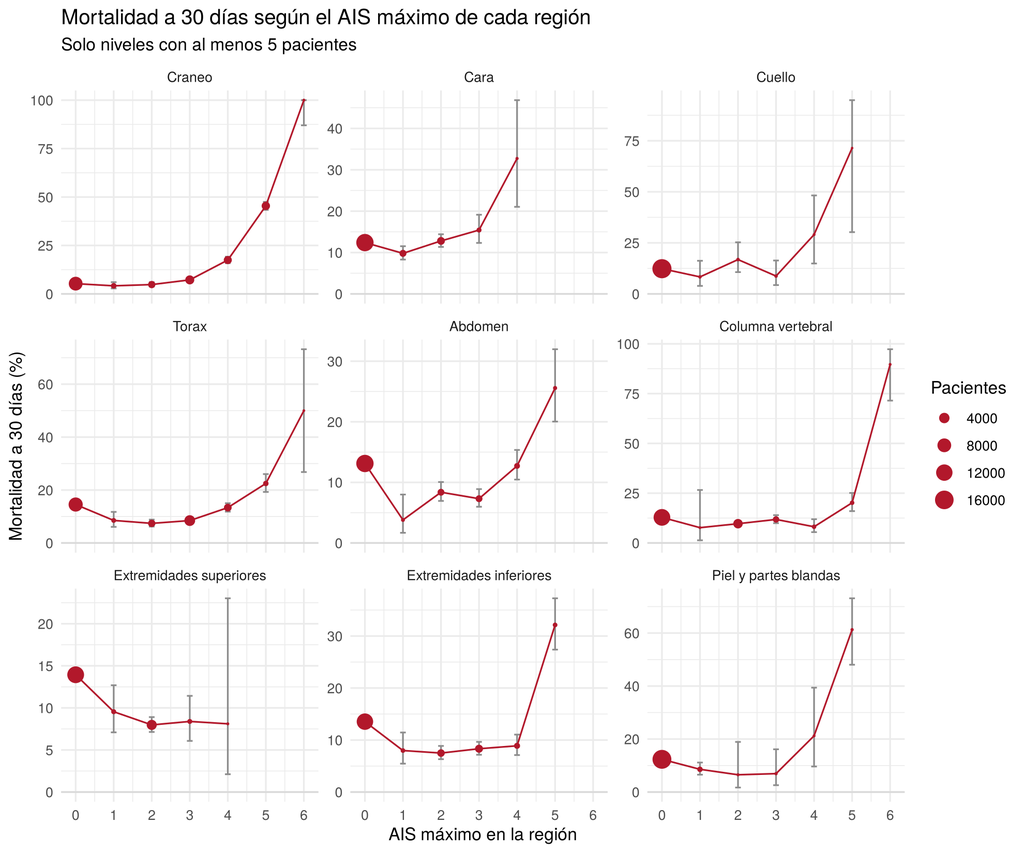

```r
ggplot(subset(level_table, n >= 5),
       aes(x = AIS, y = mortalidad)) +
  geom_hline(yintercept = 0, colour = "grey85") +
  geom_errorbar(aes(ymin = ic_inf, ymax = ic_sup), width = 0.15,
                colour = "grey55") +
  geom_line(colour = "#b2182b", linewidth = 0.5) +
  geom_point(aes(size = n), colour = "#b2182b") +
  scale_x_continuous(breaks = 0:6) +
  scale_size_area(max_size = 5) +
  facet_wrap(~Region, ncol = 3, scales = "free_y") +
  labs(x = "AIS máximo en la región", y = "Mortalidad a 30 días (%)",
       size = "Pacientes",
       title = "Mortalidad a 30 días según el AIS máximo de cada región",
       subtitle = "Solo niveles con al menos 5 pacientes") +
  theme_minimal(base_size = 11)
```

```r
ggsave(file.path(output_dir, "mortalidad_por_nivel_ais.png"),
       width = 10, height = 7.5, dpi = 150)
```

# 5 Puntos de corte por región (todos los pacientes)

## 5.1 Funciones de búsqueda de cortes

El predictor es un entero 0-6, de modo que un corte `k` significa **AIS >= k** frente a **AIS < k** (k = 1, …, 6). Para cada corte se calculan mortalidad a cada lado, sensibilidad, especificidad, índice de Youden, odds ratio y p-valor de chi-cuadrado. Solo se admiten cortes con al menos `min_bucket` pacientes en cada lado.

```r
# Tabla de cortes a partir de los conteos por nivel AIS (0..6).
cut_table_counts <- function(n_all, d_all, min_bucket) {
  N_tot <- sum(n_all)
  D_tot <- sum(d_all)
  S_tot <- N_tot - D_tot
  n_ge <- rev(cumsum(rev(n_all)))   # n_ge[k + 1] = pacientes con AIS >= k
  d_ge <- rev(cumsum(rev(d_all)))
  cuts <- 1:6
  n_hi <- n_ge[cuts + 1]
  d_hi <- d_ge[cuts + 1]
  n_lo <- N_tot - n_hi
  d_lo <- D_tot - d_hi
  s_hi <- n_hi - d_hi
  s_lo <- n_lo - d_lo
  sens <- d_hi / D_tot
  spec <- s_lo / S_tot
  valid <- n_hi >= min_bucket & n_lo >= min_bucket
  data.frame(
    corte = cuts, n_bajo = n_lo, n_alto = n_hi,
    mort_bajo = 100 * d_lo / pmax(n_lo, 1), mort_alto = 100 * d_hi / pmax(n_hi, 1),
    sens = sens, spec = spec, youden = ifelse(valid, sens + spec - 1, NA_real_),
    d_hi = d_hi, d_lo = d_lo, s_hi = s_hi, s_lo = s_lo, valido = valid
  )
}

best_cut_youden <- function(n_all, d_all, min_bucket) {
  tab <- cut_table_counts(n_all, d_all, min_bucket)
  if (all(is.na(tab$youden))) return(NA_integer_)
  tab$corte[which.max(tab$youden)]
}

odds_ratio <- function(d_hi, s_hi, d_lo, s_lo) {
  cells <- c(d_hi, s_hi, d_lo, s_lo)
  if (any(cells == 0)) cells <- cells + 0.5   # corrección de Haldane
  (cells[1] * cells[4]) / (cells[2] * cells[3])
}

chisq_p <- function(d_hi, s_hi, d_lo, s_lo) {
  m <- matrix(c(d_hi, s_hi, d_lo, s_lo), 2, byrow = TRUE)
  if (any(rowSums(m) == 0) || any(colSums(m) == 0)) return(NA_real_)
  suppressWarnings(chisq.test(m, correct = FALSE)$p.value)
}

# Corte de un árbol rpart con una sola partición (criterio de Gini).
# cp = -1 obliga a rpart a dividir aunque la partición no cambie la clase
# predicha (con predictor ordinal y mortalidad baja, cp = 0 deja solo la raíz).
rpart_cut <- function(x, y, min_bucket) {
  df <- data.frame(x = x, y = factor(y, levels = c(0, 1)))
  fit <- rpart(y ~ x, data = df, method = "class",
               control = rpart.control(maxdepth = 1L, cp = -1, xval = 0,
                                       minbucket = min_bucket,
                                       maxcompete = 0L, maxsurrogate = 0L))
  if (nrow(fit$frame) < 3L) return(NA_integer_)
  as.integer(ceiling(fit$splits[1, "index"]))
}

# Corte de un árbol de inferencia condicional con una sola partición.
ctree_cut <- function(x, y, min_bucket) {
  df <- data.frame(x = as.numeric(x), y = factor(y, levels = c(0, 1)))
  ct <- ctree(y ~ x, data = df,
              control = ctree_control(maxdepth = 1L, minbucket = min_bucket,
                                      alpha = 0.05, testtype = "Bonferroni"))
  if (width(ct) < 2L) return(c(corte = NA_real_, p = NA_real_))
  node <- node_party(ct)
  c(corte = floor(breaks_split(split_node(node))) + 1,
    p = as.numeric(info_node(node)$p.value))
}

# Bootstrap: frecuencia con la que cada corte es el elegido por Youden.
bootstrap_cut <- function(x, y, min_bucket, B) {
  N_x <- length(x)
  picks <- integer(B)
  for (b in seq_len(B)) {
    idx <- sample.int(N_x, replace = TRUE)
    xb <- x[idx]
    yb <- y[idx]
    picks[b] <- best_cut_youden(tabulate(xb + 1L, nbins = 7L),
                                tabulate(xb[yb == 1L] + 1L, nbins = 7L),
                                min_bucket)
  }
  freq <- tabulate(picks[!is.na(picks)], nbins = 6L) / B
  names(freq) <- paste0("AIS>=", 1:6)
  freq
}

analyse_region <- function(x, y, min_bucket, B) {
  n_all <- tabulate(x + 1L, nbins = 7L)
  d_all <- tabulate(x[y == 1L] + 1L, nbins = 7L)
  tab <- cut_table_counts(n_all, d_all, min_bucket)
  tab$or <- mapply(odds_ratio, tab$d_hi, tab$s_hi, tab$d_lo, tab$s_lo)
  tab$p <- mapply(chisq_p, tab$d_hi, tab$s_hi, tab$d_lo, tab$s_lo)
  list(
    table = tab,
    youden = best_cut_youden(n_all, d_all, min_bucket),
    rpart = rpart_cut(x, y, min_bucket),
    ctree = ctree_cut(x, y, min_bucket),
    boot = if (B > 0) bootstrap_cut(x, y, min_bucket, B) else rep(NA_real_, 6)
  )
}

auc_value <- function(x, y) {
  if (length(unique(y)) < 2L || length(unique(x)) < 2L) return(NA_real_)
  as.numeric(auc(roc(y, x, quiet = TRUE, direction = "<")))
}
```

## 5.2 Resultados por región

```r
results_all <- lapply(region_vars, function(v) {
  analyse_region(ais_df[[v]], died, min_bucket_univariate, n_bootstrap)
})
names(results_all) <- region_names

format_p <- function(p) {
  ifelse(is.na(p), NA_character_, ifelse(p < 0.001, "<0.001", sprintf("%.3f", p)))
}

# Si el mejor corte tiene Youden <= 0, ningún corte identifica un grupo de
# mayor mortalidad y no se propone corte (se devuelve NA).
summary_cuts <- function(results, data_list, region_labels) {
  do.call(rbind, lapply(seq_along(results), function(i) {
    r <- results[[i]]
    x <- data_list[[i]]$x
    y <- data_list[[i]]$y
    tab <- r$table
    k <- r$youden
    if (!is.na(k) && tab$youden[tab$corte == k] <= 0) k <- NA_integer_
    row_k <- if (is.na(k)) NULL else tab[tab$corte == k, ]
    k_ct <- unname(r$ctree["corte"])
    row_ct <- if (is.na(k_ct) || !(k_ct %in% 1:6)) NULL else tab[tab$corte == k_ct, ]
    row_ref <- tab[tab$corte == severe_threshold, ]
    data.frame(
      Region = region_labels[i],
      n = length(x), muertes = sum(y),
      mortalidad_global = round(100 * mean(y), 1),
      AUC_AIS_continuo = round(auc_value(x, y), 3),
      corte_Youden = ifelse(is.na(k), NA, k),
      estabilidad_Youden = ifelse(is.na(k), NA, round(100 * r$boot[k], 1)),
      n_alto = if (is.null(row_k)) NA else row_k$n_alto,
      mort_bajo = if (is.null(row_k)) NA else round(row_k$mort_bajo, 1),
      mort_alto = if (is.null(row_k)) NA else round(row_k$mort_alto, 1),
      sens = if (is.null(row_k)) NA else round(100 * row_k$sens, 1),
      spec = if (is.null(row_k)) NA else round(100 * row_k$spec, 1),
      youden = if (is.null(row_k)) NA else round(row_k$youden, 3),
      OR = if (is.null(row_k)) NA else round(row_k$or, 1),
      youden_corte3 = if (nrow(row_ref) == 0 || is.na(row_ref$youden)) NA
                      else round(row_ref$youden, 3),
      corte_rpart = r$rpart,
      corte_ctree = k_ct,
      p_ctree = format_p(unname(r$ctree["p"])),
      mort_bajo_ctree = if (is.null(row_ct)) NA else round(row_ct$mort_bajo, 1),
      mort_alto_ctree = if (is.null(row_ct)) NA else round(row_ct$mort_alto, 1),
      stringsAsFactors = FALSE
    )
  }))
}

cuts_col_names <- c(
  "Región", "n", "Muertes", "Mort. global %", "AUC (AIS continuo)",
  "Corte Youden", "Estabilidad Youden %", "n con AIS >= corte",
  "Mort. < corte %", "Mort. >= corte %", "Sens %", "Espec %", "Youden", "OR",
  "Youden con AIS>=3", "Corte rpart", "Corte ctree", "p ctree",
  "Mort. < corte ctree %", "Mort. >= corte ctree %"
)

data_all <- lapply(region_vars, function(v) list(x = ais_df[[v]], y = died))
cuts_all <- summary_cuts(results_all, data_all, region_names)

knitr::kable(
  cuts_all,
  col.names = cuts_col_names,
  caption = paste0(
    "Cortes de AIS máximo por región (pacientes con AIS 0 incluidos). ",
    "'Corte k' significa AIS >= k. La estabilidad es el % de réplicas ",
    "bootstrap en que Youden elige ese mismo corte. Corte Youden vacío: ",
    "ningún corte identifica un grupo con mayor mortalidad (Youden <= 0). ",
    "rpart y ctree buscan la mejor partición sin exigir que la mortalidad ",
    "sea mayor por encima del corte: compare las dos últimas columnas.")
)
```

Cortes de AIS máximo por región (pacientes con AIS 0 incluidos). ‘Corte k’ significa AIS >= k. La estabilidad es el % de réplicas bootstrap en que Youden elige ese mismo corte. Corte Youden vacío: ningún corte identifica un grupo con mayor mortalidad (Youden <= 0). rpart y ctree buscan la mejor partición sin exigir que la mortalidad sea mayor por encima del corte: compare las dos últimas columnas.

| Región | n | Muertes | Mort. global % | AUC (AIS continuo) | Corte Youden | Estabilidad Youden % | n con AIS >= corte | Mort. < corte % | Mort. >= corte % | Sens % | Espec % | Youden | OR | Youden con AIS>=3 | Corte rpart | Corte ctree | p ctree | Mort. < corte ctree % | Mort. >= corte ctree % |
| --- | --- | --- | --- | --- | --- | --- | --- | --- | --- | --- | --- | --- | --- | --- | --- | --- | --- | --- | --- |
| Craneo | 17366 | 2151 | 12.4 | 0.763 | 4 | 100.0 | 4360 | 5.6 | 32.6 | 66.2 | 80.7 | 0.469 | 8.2 | 0.393 | 5 | 5 | <0.001 | 7.2 | 46.2 |
| Cara | 17366 | 2151 | 12.4 | 0.502 | 2 | 72.3 | 2389 | 12.2 | 13.8 | 15.3 | 86.5 | 0.018 | 1.2 | 0.013 | 4 | NA | NA | NA | NA |
| Cuello | 17366 | 2151 | 12.4 | 0.502 | 2 | 56.0 | 254 | 12.3 | 16.5 | 2.0 | 98.6 | 0.006 | 1.4 | 0.003 | 4 | 2 | 0.017 | 12.3 | 16.5 |
| Torax | 17366 | 2151 | 12.4 | 0.473 | 4 | 91.0 | 2440 | 11.8 | 15.9 | 18.0 | 86.5 | 0.045 | 1.4 | -0.046 | 1 | 1 | <0.001 | 14.5 | 10.3 |
| Abdomen | 17366 | 2151 | 12.4 | 0.477 | 4 | 60.7 | 976 | 12.2 | 15.8 | 7.2 | 94.6 | 0.018 | 1.4 | -0.017 | 5 | 5 | 0.006 | 12.2 | 26.2 |
| Columna vertebral | 17366 | 2151 | 12.4 | 0.489 | 5 | 93.3 | 346 | 12.1 | 26.0 | 4.2 | 98.3 | 0.025 | 2.6 | 0.015 | 5 | NA | NA | NA | NA |
| Extremidades superiores | 17366 | 2151 | 12.4 | 0.447 | NA | NA | NA | NA | NA | NA | NA | NA | NA | -0.010 | 1 | 1 | <0.001 | 13.9 | 8.2 |
| Extremidades inferiores | 17366 | 2151 | 12.4 | 0.471 | 5 | 100.0 | 361 | 12.0 | 32.1 | 5.4 | 98.4 | 0.038 | 3.5 | -0.021 | 5 | 5 | 0.002 | 12.0 | 32.1 |
| Piel y partes blandas | 17366 | 2151 | 12.4 | 0.502 | 4 | 85.3 | 99 | 12.2 | 49.5 | 2.3 | 99.7 | 0.019 | 7.1 | 0.017 | 5 | 2 | <0.001 | 12.2 | 26.3 |

```r
write.csv2(cuts_all, file.path(output_dir, "cortes_por_region_todos.csv"),
           row.names = FALSE)
```

## 5.3 Estabilidad del corte por bootstrap

```r
stability_all <- do.call(rbind, lapply(seq_along(results_all), function(i) {
  data.frame(Region = region_names[i], corte = 1:6,
             frecuencia = 100 * results_all[[i]]$boot)
}))
stability_all$Region <- factor(stability_all$Region, levels = region_names)

stab_wide <- reshape(stability_all, idvar = "Region", timevar = "corte",
                     direction = "wide")
names(stab_wide) <- c("Región", paste0("AIS>=", 1:6))
knitr::kable(stab_wide, digits = 1, row.names = FALSE,
             caption = "% de réplicas bootstrap en que Youden elige cada corte")
```

% de réplicas bootstrap en que Youden elige cada corte

| Región | AIS>=1 | AIS>=2 | AIS>=3 | AIS>=4 | AIS>=5 | AIS>=6 |
| --- | --- | --- | --- | --- | --- | --- |
| Craneo | 0.0 | 0.0 | 0.0 | 100.0 | 0.0 | 0 |
| Cara | 0.0 | 72.3 | 27.0 | 0.7 | 0.0 | 0 |
| Cuello | 4.8 | 56.0 | 1.6 | 37.6 | 0.0 | 0 |
| Torax | 0.0 | 0.0 | 0.0 | 91.0 | 9.0 | 0 |
| Abdomen | 0.0 | 0.0 | 0.0 | 60.7 | 39.3 | 0 |
| Columna vertebral | 0.0 | 0.0 | 6.1 | 0.6 | 93.3 | 0 |
| Extremidades superiores | 0.0 | 0.0 | 10.0 | 90.0 | 0.0 | 0 |
| Extremidades inferiores | 0.0 | 0.0 | 0.0 | 0.0 | 100.0 | 0 |
| Piel y partes blandas | 0.0 | 0.5 | 4.8 | 85.3 | 9.4 | 0 |

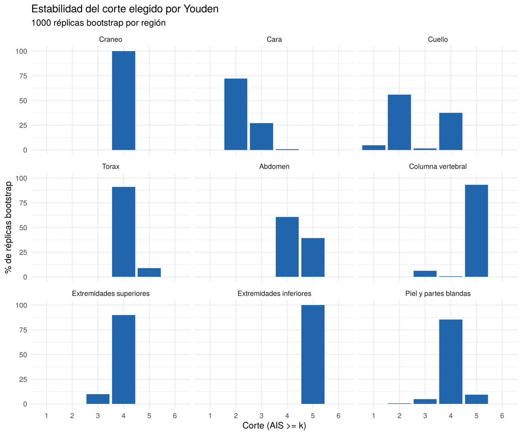

```r
write.csv2(stability_all, file.path(output_dir, "estabilidad_bootstrap_todos.csv"),
           row.names = FALSE)

ggplot(stability_all, aes(x = factor(corte), y = frecuencia)) +
  geom_col(fill = "#2166ac") +
  facet_wrap(~Region, ncol = 3) +
  labs(x = "Corte (AIS >= k)", y = "% de réplicas bootstrap",
       title = "Estabilidad del corte elegido por Youden",
       subtitle = paste0(n_bootstrap, " réplicas bootstrap por región")) +
  theme_minimal(base_size = 11)
```

```r
ggsave(file.path(output_dir, "estabilidad_bootstrap_todos.png"),
       width = 10, height = 7.5, dpi = 150)
```

## 5.4 Curva de Youden por corte

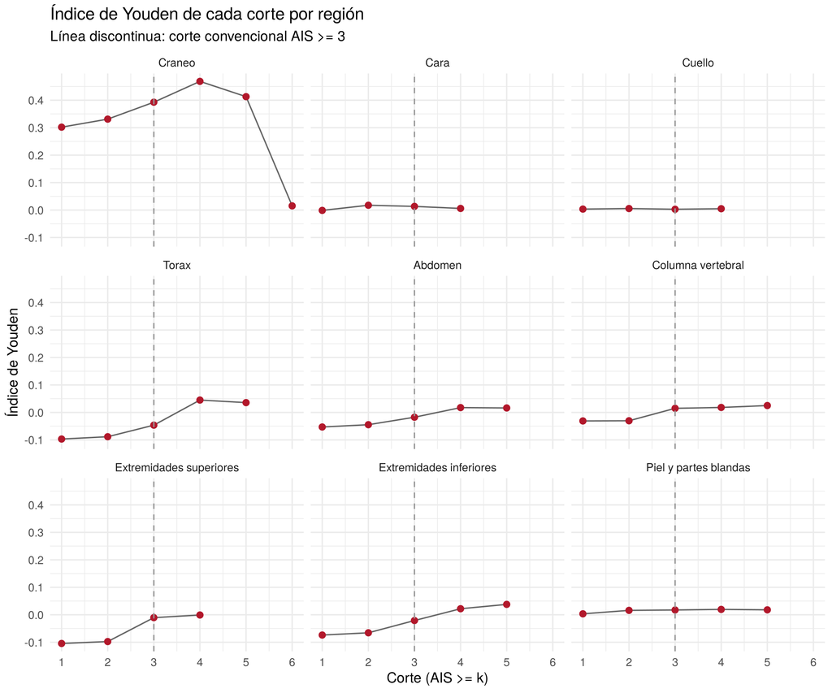

```r
youden_curves <- do.call(rbind, lapply(seq_along(results_all), function(i) {
  tab <- results_all[[i]]$table
  data.frame(Region = region_names[i], corte = tab$corte, youden = tab$youden)
}))
youden_curves$Region <- factor(youden_curves$Region, levels = region_names)

ggplot(youden_curves, aes(x = corte, y = youden)) +
  geom_line(colour = "grey40", na.rm = TRUE) +
  geom_point(colour = "#b2182b", size = 2, na.rm = TRUE) +
  geom_vline(xintercept = severe_threshold, linetype = "dashed",
             colour = "grey60") +
  scale_x_continuous(breaks = 1:6) +
  facet_wrap(~Region, ncol = 3) +
  labs(x = "Corte (AIS >= k)", y = "Índice de Youden",
       title = "Índice de Youden de cada corte por región",
       subtitle = "Línea discontinua: corte convencional AIS >= 3") +
  theme_minimal(base_size = 11)
```

```r
ggsave(file.path(output_dir, "youden_por_corte.png"),
       width = 10, height = 7.5, dpi = 150)
```

# 6 Puntos de corte con lesión aislada en la región

Los cortes de la sección anterior pueden estar influidos por lesiones graves en **otras regiones** (por ejemplo, un AIS 3 de extremidad inferior en un politraumatizado con TCE grave). Aquí se repite el análisis solo con pacientes que tienen **lesión en esa región (AIS >= 1) y ninguna lesión grave (AIS >= 3) en las demás regiones**, de modo que el corte refleje el efecto propio de la región.

```r
results_isolated <- vector("list", length(region_vars))
data_isolated <- vector("list", length(region_vars))
for (i in seq_along(region_vars)) {
  others <- setdiff(region_vars, region_vars[i])
  other_max <- apply(as.matrix(ais_df[others]), 1, max)
  isolated <- ais_df[[region_vars[i]]] >= 1L & other_max < severe_threshold
  x <- ais_df[[region_vars[i]]][isolated]
  y <- died[isolated]
  data_isolated[[i]] <- list(x = x, y = y)
  results_isolated[[i]] <- if (length(unique(y)) < 2L) {
    NULL
  } else {
    analyse_region(x, y, min_bucket_isolated, n_bootstrap)
  }
}
names(results_isolated) <- region_names

ok <- !vapply(results_isolated, is.null, logical(1))
cuts_isolated <- summary_cuts(results_isolated[ok], data_isolated[ok],
                              region_names[ok])
cuts_isolated$youden_corte3 <- NULL

knitr::kable(
  cuts_isolated,
  col.names = cuts_col_names[cuts_col_names != "Youden con AIS>=3"],
  caption = paste0(
    "Cortes de AIS máximo por región en pacientes con lesión aislada ",
    "(AIS >= 1 en la región y AIS < ", severe_threshold,
    " en las demás). Mínimo ", min_bucket_isolated,
    " pacientes a cada lado del corte.")
)
```

Cortes de AIS máximo por región en pacientes con lesión aislada (AIS >= 1 en la región y AIS < 3 en las demás). Mínimo 20 pacientes a cada lado del corte.

| Región | n | Muertes | Mort. global % | AUC (AIS continuo) | Corte Youden | Estabilidad Youden % | n con AIS >= corte | Mort. < corte % | Mort. >= corte % | Sens % | Espec % | Youden | OR | Corte rpart | Corte ctree | p ctree | Mort. < corte ctree % | Mort. >= corte ctree % |
| --- | --- | --- | --- | --- | --- | --- | --- | --- | --- | --- | --- | --- | --- | --- | --- | --- | --- | --- |
| Craneo | 5391 | 1007 | 18.7 | 0.785 | 5 | 100.0 | 1553 | 8.5 | 43.8 | 67.5 | 80.1 | 0.476 | 8.4 | 5 | 5 | <0.001 | 8.5 | 43.8 |
| Cara | 594 | 16 | 2.7 | 0.532 | 2 | 95.6 | 371 | 1.8 | 3.2 | 75.0 | 37.9 | 0.129 | 1.8 | 2 | NA | NA | NA | NA |
| Cuello | 124 | 6 | 4.8 | 0.823 | 3 | 89.6 | 61 | 1.6 | 8.2 | 83.3 | 52.5 | 0.359 | 5.5 | 3 | 3 | <0.001 | 1.6 | 8.2 |
| Torax | 3457 | 110 | 3.2 | 0.684 | 4 | 99.1 | 1013 | 1.9 | 6.2 | 57.3 | 71.6 | 0.289 | 3.4 | 5 | 5 | <0.001 | 2.6 | 11.8 |
| Abdomen | 1082 | 29 | 2.7 | 0.705 | 4 | 94.0 | 311 | 1.3 | 6.1 | 65.5 | 72.3 | 0.378 | 5.0 | 5 | 5 | <0.001 | 2.0 | 14.3 |
| Columna vertebral | 979 | 74 | 7.6 | 0.810 | 5 | 90.9 | 160 | 2.9 | 31.2 | 67.6 | 87.8 | 0.554 | 15.1 | 5 | 5 | <0.001 | 2.9 | 31.2 |
| Extremidades superiores | 593 | 9 | 1.5 | 0.369 | NA | NA | NA | NA | NA | NA | NA | NA | NA | 3 | NA | NA | NA | NA |
| Extremidades inferiores | 1556 | 45 | 2.9 | 0.665 | 5 | 85.4 | 79 | 2.0 | 19.0 | 33.3 | 95.8 | 0.291 | 11.3 | 5 | 5 | <0.001 | 2.0 | 19.0 |
| Piel y partes blandas | 316 | 37 | 11.7 | 0.921 | 5 | 54.1 | 54 | 2.3 | 57.4 | 83.8 | 91.8 | 0.755 | 57.5 | 5 | 5 | <0.001 | 2.3 | 57.4 |

```r
write.csv2(cuts_isolated, file.path(output_dir, "cortes_por_region_aislados.csv"),
           row.names = FALSE)

if (any(!ok)) {
  cat("Regiones sin pacientes suficientes para este análisis:",
      paste(region_names[!ok], collapse = ", "), "\n")
}
```

# 7 Árbol multivariante con las 9 regiones

Ahora las 9 regiones entran **a la vez** en un mismo árbol. Así se obtiene una jerarquía de cortes: qué región se examina primero, con qué AIS, y cómo cambia la mortalidad en cada rama. Se usa una muestra de **entrenamiento** (70%) para ajustar el árbol y una muestra de **test** (30%), estratificada por desenlace, para medir cuánto discrimina fuera de la muestra en la que se construyó.

```r
tree_data <- ais_df
tree_data$died <- factor(died, levels = c(0, 1))

test_idx <- unlist(lapply(split(seq_len(N), died), function(idx) {
  sample(idx, size = round(test_fraction * length(idx)))
}))
train <- tree_data[-test_idx, ]
test <- tree_data[test_idx, ]
cat("Entrenamiento:", nrow(train), "pacientes,", sum(train$died == 1),
    "fallecidos | Test:", nrow(test), "pacientes,", sum(test$died == 1),
    "fallecidos\n")
```

```
## Entrenamiento: 12157 pacientes, 1506 fallecidos | Test: 5209 pacientes, 645 fallecidos
```

## 7.1 Árbol de inferencia condicional (`ctree`)

```r
ct <- ctree(died ~ ., data = train,
            control = ctree_control(alpha = 0.01, testtype = "Bonferroni",
                                    minbucket = min_bucket_tree,
                                    maxdepth = max_depth_tree))
print(ct)
```

```
##
## Model formula:
## died ~ Craneo + Cara + Cuello + Torax + Abdomen + Columna + Ext_sup +
##     Ext_inf + Piel
##
## Fitted party:
## [1] root
## |   [2] Craneo <= 4
## |   |   [3] Craneo <= 3
## |   |   |   [4] Piel <= 2
## |   |   |   |   [5] Columna <= 4: 0 (n = 8794, err = 4.9%)
## |   |   |   |   [6] Columna > 4: 0 (n = 211, err = 20.4%)
## |   |   |   [7] Piel > 2
## |   |   |   |   [8] Piel <= 3: 0 (n = 51, err = 7.8%)
## |   |   |   |   [9] Piel > 3: 0 (n = 67, err = 43.3%)
## |   |   [10] Craneo > 3
## |   |   |   [11] Torax <= 2: 0 (n = 1127, err = 15.5%)
## |   |   |   [12] Torax > 2: 0 (n = 300, err = 25.7%)
## |   [13] Craneo > 4: 0 (n = 1607, err = 46.6%)
##
## Number of inner nodes:    6
## Number of terminal nodes: 7
```

```r
png(file.path(output_dir, "ctree_9_regiones.png"), width = 1800, height = 1100,
    res = 130)
plot(ct, main = "ctree: mortalidad a 30 días según AIS máximo por región")
dev.off()
```

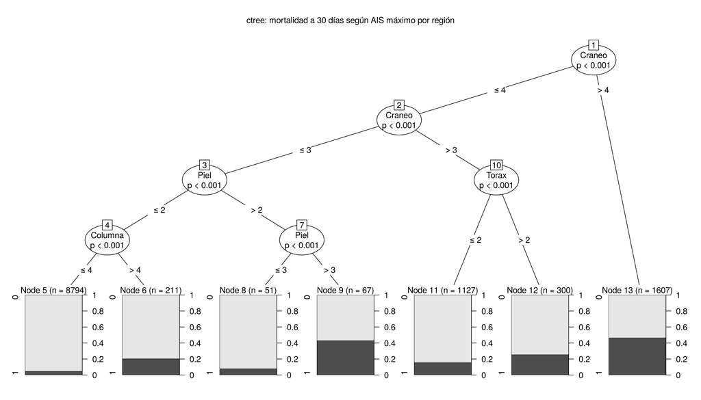

```r
plot(ct, main = "ctree: mortalidad a 30 días según AIS máximo por región")
```

```r
ct_splits <- function(ct_fit) {
  out <- list()
  walk <- function(node) {
    if (is.terminal(node)) return(invisible())
    sp <- split_node(node)
    out[[length(out) + 1L]] <<- data.frame(
      nodo = id_node(node),
      region = names(ct_fit$data)[varid_split(sp)],
      corte = paste0("AIS >= ", floor(breaks_split(sp)) + 1)
    )
    for (kid in kids_node(node)) walk(kid)
  }
  walk(node_party(ct_fit))
  do.call(rbind, out)
}

ct_cut_table <- ct_splits(ct)
knitr::kable(ct_cut_table, row.names = FALSE,
             caption = "Particiones del ctree (nodo, región y corte)")
```

Particiones del ctree (nodo, región y corte)

| nodo | region | corte |
| --- | --- | --- |
| 1 | Craneo | AIS >= 5 |
| 2 | Craneo | AIS >= 4 |
| 3 | Piel | AIS >= 3 |
| 4 | Columna | AIS >= 5 |
| 7 | Piel | AIS >= 4 |
| 10 | Torax | AIS >= 3 |

```r
leaf_table <- function(fit, data) {
  node <- predict(fit, newdata = data, type = "node")
  agg <- data.frame(nodo = as.integer(names(table(node))),
                    n = as.integer(table(node)))
  agg$muertes <- as.integer(tapply(as.integer(as.character(data$died)),
                                   node, sum))
  agg$mortalidad <- round(100 * agg$muertes / agg$n, 1)
  agg[order(agg$mortalidad), ]
}
ct_leaves <- leaf_table(ct, train)
knitr::kable(ct_leaves, row.names = FALSE,
             caption = "Hojas del ctree (muestra de entrenamiento)")
```

Hojas del ctree (muestra de entrenamiento)

| nodo | n | muertes | mortalidad |
| --- | --- | --- | --- |
| 5 | 8794 | 429 | 4.9 |
| 8 | 51 | 4 | 7.8 |
| 11 | 1127 | 175 | 15.5 |
| 6 | 211 | 43 | 20.4 |
| 12 | 300 | 77 | 25.7 |
| 9 | 67 | 29 | 43.3 |
| 13 | 1607 | 749 | 46.6 |

```r
write.csv2(ct_cut_table, file.path(output_dir, "ctree_cortes.csv"),
           row.names = FALSE)
write.csv2(ct_leaves, file.path(output_dir, "ctree_hojas.csv"), row.names = FALSE)
```

## 7.2 Árbol de clasificación (`rpart`) podado

El árbol completo se poda con la regla de **1 error estándar** sobre la validación cruzada interna de 10 pliegues.

```r
set.seed(seed)
rp_full <- rpart(died ~ ., data = train, method = "class",
                 control = rpart.control(cp = 0.0005, minbucket = min_bucket_tree,
                                         xval = 10L, maxcompete = 0L,
                                         maxsurrogate = 0L))
cp_tab <- rp_full$cptable
best_row <- which.min(cp_tab[, "xerror"])
threshold <- cp_tab[best_row, "xerror"] + cp_tab[best_row, "xstd"]
cp_1se <- cp_tab[which(cp_tab[, "xerror"] <= threshold)[1], "CP"]
rp <- prune(rp_full, cp = cp_1se)

cat("CP elegido (regla 1-SE):", signif(cp_1se, 3), "\n\n")
```

```
## CP elegido (regla 1-SE): 0.00365
```

```r
print(rp)
```

```
## n= 12157
##
## node), split, n, loss, yval, (yprob)
##       * denotes terminal node
##
## 1) root 12157 1506 0 (0.87612075 0.12387925)
##   2) Craneo< 4.5 10550  757 0 (0.92824645 0.07175355) *
##   3) Craneo>=4.5 1607  749 0 (0.53391413 0.46608587)
##     6) Torax< 3.5 1438  641 0 (0.55424200 0.44575800) *
##     7) Torax>=3.5 169   61 1 (0.36094675 0.63905325) *
```

```r
rp_vars <- as.character(rp$frame$var)
rp_split_rows <- rp_vars != "<leaf>"
rp_cut_table <- data.frame(
  nodo = as.integer(rownames(rp$frame))[rp_split_rows],
  region = rp_vars[rp_split_rows],
  corte = paste0("AIS >= ", ceiling(rp$splits[, "index"]))
)
knitr::kable(rp_cut_table, row.names = FALSE,
             caption = "Particiones del rpart podado (nodo, región y corte)")
```

Particiones del rpart podado (nodo, región y corte)

| nodo | region | corte |
| --- | --- | --- |
| 1 | Craneo | AIS >= 5 |
| 3 | Torax | AIS >= 4 |

```r
write.csv2(rp_cut_table, file.path(output_dir, "rpart_cortes.csv"),
           row.names = FALSE)

rp_party <- as.party(rp)
png(file.path(output_dir, "rpart_9_regiones.png"), width = 1800, height = 1100,
    res = 130)
plot(rp_party, main = "rpart podado: mortalidad a 30 días según AIS máximo por región")
dev.off()
```

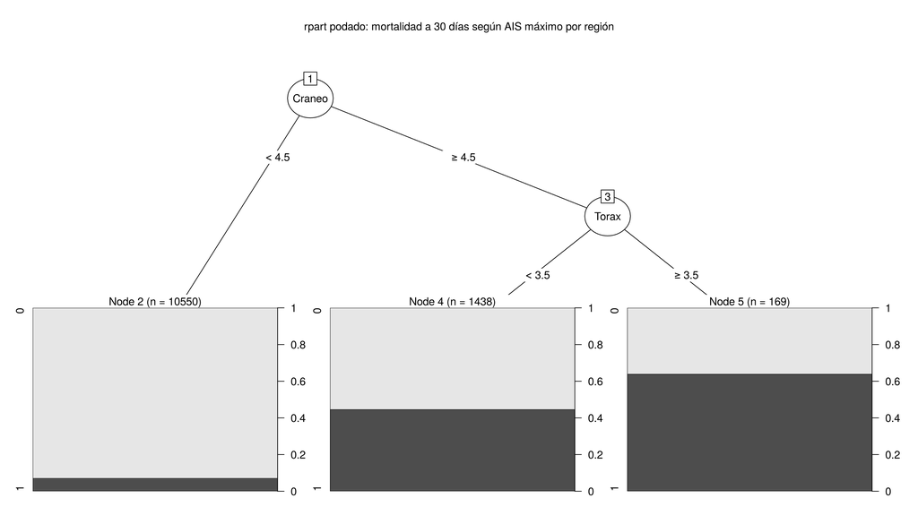

```r
plot(rp_party, main = "rpart podado: mortalidad a 30 días según AIS máximo por región")
```

## 7.3 Rendimiento en la muestra de test

Se compara el rendimiento de los árboles con dos regresiones logísticas de referencia: una con el AIS máximo de cada región como variable continua y otra con el indicador convencional AIS >= 3 por región. La comparación indica cuánta información se pierde (o se gana) al resumir cada región con unos pocos cortes.

```r
prob_1 <- function(p) if (is.matrix(p)) p[, "1"] else as.numeric(p)

dich <- function(d) {
  out <- as.data.frame(lapply(d[region_vars],
                              function(v) as.integer(v >= severe_threshold)))
  out$died <- d$died
  out
}

fit_glm_cont <- glm(died ~ ., data = train, family = binomial)
fit_glm_dich <- glm(died ~ ., data = dich(train), family = binomial)

models <- list(
  "ctree (9 regiones)" = prob_1(predict(ct, newdata = test, type = "prob")),
  "rpart podado (9 regiones)" = prob_1(predict(rp, newdata = test, type = "prob")),
  "Logistica, AIS continuo" = as.numeric(predict(fit_glm_cont, newdata = test,
                                                 type = "response")),
  "Logistica, AIS >= 3 por region" = as.numeric(
    predict(fit_glm_dich, newdata = dich(test), type = "response"))
)

test_y <- as.integer(as.character(test$died))
auc_table <- do.call(rbind, lapply(names(models), function(nm) {
  r <- roc(test_y, models[[nm]], quiet = TRUE, direction = "<")
  ci <- ci.auc(r, method = "delong")
  data.frame(Modelo = nm, AUC = round(as.numeric(r$auc), 3),
             IC95_inf = round(ci[1], 3), IC95_sup = round(ci[3], 3))
}))
knitr::kable(auc_table, row.names = FALSE,
             caption = "AUC en la muestra de test (IC 95% de DeLong)")
```

AUC en la muestra de test (IC 95% de DeLong)

| Modelo | AUC | IC95_inf | IC95_sup |
| --- | --- | --- | --- |
| ctree (9 regiones) | 0.774 | 0.754 | 0.793 |
| rpart podado (9 regiones) | 0.703 | 0.683 | 0.723 |
| Logistica, AIS continuo | 0.790 | 0.770 | 0.810 |
| Logistica, AIS >= 3 por region | 0.736 | 0.717 | 0.754 |

```r
write.csv2(auc_table, file.path(output_dir, "auc_test_modelos.csv"),
           row.names = FALSE)
```

# 8 Árbol con la edad como variable adicional

La edad es uno de los predictores más fuertes de mortalidad en trauma, y puede desplazar a las regiones anatómicas en la jerarquía del árbol. Este ctree añade la edad a las 9 regiones para ver qué cortes de región sobreviven.

```r
tree_data_age <- tree_data
tree_data_age$edad <- age
train_age <- tree_data_age[-test_idx, ]
test_age <- tree_data_age[test_idx, ]

ct_age <- ctree(died ~ ., data = train_age,
                control = ctree_control(alpha = 0.01, testtype = "Bonferroni",
                                        minbucket = min_bucket_tree,
                                        maxdepth = max_depth_tree))
print(ct_age)
```

```
##
## Model formula:
## died ~ Craneo + Cara + Cuello + Torax + Abdomen + Columna + Ext_sup +
##     Ext_inf + Piel + edad
##
## Fitted party:
## [1] root
## |   [2] Craneo <= 4
## |   |   [3] edad <= 74
## |   |   |   [4] Piel <= 2
## |   |   |   |   [5] Craneo <= 3: 0 (n = 8062, err = 3.5%)
## |   |   |   |   [6] Craneo > 3: 0 (n = 1214, err = 13.9%)
## |   |   |   [7] Piel > 2: 0 (n = 110, err = 26.4%)
## |   |   [8] edad > 74
## |   |   |   [9] edad <= 82
## |   |   |   |   [10] Craneo <= 3: 0 (n = 712, err = 16.6%)
## |   |   |   |   [11] Craneo > 3: 0 (n = 160, err = 31.9%)
## |   |   |   [12] edad > 82
## |   |   |   |   [13] Craneo <= 3: 0 (n = 240, err = 30.8%)
## |   |   |   |   [14] Craneo > 3: 1 (n = 52, err = 38.5%)
## |   [15] Craneo > 4
## |   |   [16] edad <= 66
## |   |   |   [17] Torax <= 3
## |   |   |   |   [18] Abdomen <= 1: 0 (n = 892, err = 34.2%)
## |   |   |   |   [19] Abdomen > 1: 1 (n = 68, err = 45.6%)
## |   |   |   [20] Torax > 3: 1 (n = 146, err = 39.0%)
## |   |   [21] edad > 66
## |   |   |   [22] edad <= 78: 1 (n = 345, err = 43.5%)
## |   |   |   [23] edad > 78: 1 (n = 156, err = 21.2%)
##
## Number of inner nodes:    11
## Number of terminal nodes: 12
```

```r
png(file.path(output_dir, "ctree_9_regiones_edad.png"), width = 1800,
    height = 1100, res = 130)
plot(ct_age, main = "ctree: 9 regiones AIS + edad")
dev.off()
```

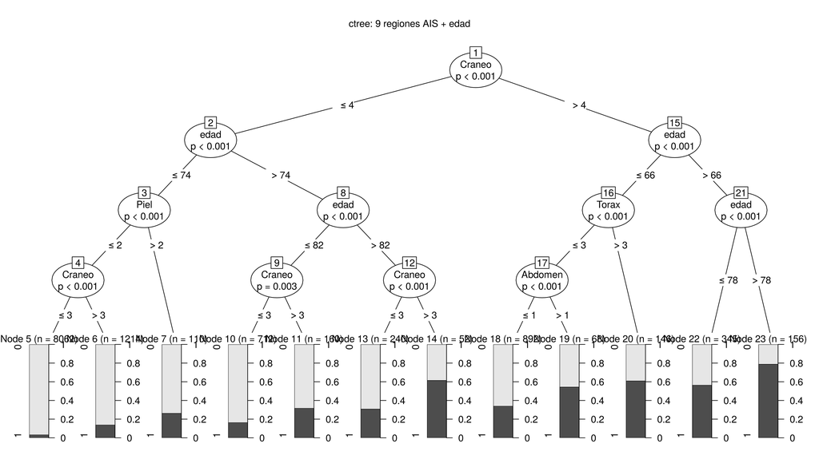

```r
plot(ct_age, main = "ctree: 9 regiones AIS + edad")
```

```r
ct_age_cuts <- ct_splits(ct_age)
ct_age_cuts$corte <- ifelse(ct_age_cuts$region == "edad",
                            sub("AIS >= ", "edad >= ", ct_age_cuts$corte),
                            ct_age_cuts$corte)
knitr::kable(ct_age_cuts, row.names = FALSE,
             caption = "Particiones del ctree con edad")
```

Particiones del ctree con edad

| nodo | region | corte |
| --- | --- | --- |
| 1 | Craneo | AIS >= 5 |
| 2 | edad | edad >= 75 |
| 3 | Piel | AIS >= 3 |
| 4 | Craneo | AIS >= 4 |
| 8 | edad | edad >= 83 |
| 9 | Craneo | AIS >= 4 |
| 12 | Craneo | AIS >= 4 |
| 15 | edad | edad >= 67 |
| 16 | Torax | AIS >= 4 |
| 17 | Abdomen | AIS >= 2 |
| 21 | edad | edad >= 79 |

```r
fit_glm_age <- glm(died ~ ., data = train_age, family = binomial)
age_models <- list(
  "ctree (9 regiones + edad)" = prob_1(predict(ct_age, newdata = test_age,
                                               type = "prob")),
  "Logistica, AIS continuo + edad" = as.numeric(
    predict(fit_glm_age, newdata = test_age, type = "response"))
)
auc_age <- do.call(rbind, lapply(names(age_models), function(nm) {
  r <- roc(test_y[!is.na(test_age$edad)],
           age_models[[nm]][!is.na(test_age$edad)], quiet = TRUE,
           direction = "<")
  ci <- ci.auc(r, method = "delong")
  data.frame(Modelo = nm, AUC = round(as.numeric(r$auc), 3),
             IC95_inf = round(ci[1], 3), IC95_sup = round(ci[3], 3))
}))
knitr::kable(auc_age, row.names = FALSE,
             caption = "AUC en test con la edad como variable adicional")
```

AUC en test con la edad como variable adicional

| Modelo | AUC | IC95_inf | IC95_sup |
| --- | --- | --- | --- |
| ctree (9 regiones + edad) | 0.815 | 0.796 | 0.833 |
| Logistica, AIS continuo + edad | 0.835 | 0.819 | 0.852 |

```r
write.csv2(rbind(auc_table, auc_age),
           file.path(output_dir, "auc_test_modelos.csv"), row.names = FALSE)
```

# 9 Cómo leer estos resultados